# R Notebook

### DAS THEMA: AUFGABE-2, Korrelation nach Bravais-Pearson (Metrisch x Metrisch)

Beschreibung

Im Rahmen einer Studie wurden Hauskatzen untersucht, dazu wurde das Gewicht der Katzen, sowie deren Herzgewicht erhoben. Es soll untersucht, ob es einen Zusammenhang zwischen dem Herzgewicht und dem Körpergewicht der Katzen besteht.

```r
data <- read.csv("uebung2.csv")
data
```

| X | Sex | Bwt | Hwt |
| --- | --- | --- | --- |
| 1 | M | 2.0 | 6.5 |
| 2 | M | 2.0 | 6.5 |
| 3 | M | 2.1 | 10.1 |
| 4 | M | 2.2 | 7.2 |
| 5 | M | 2.2 | 7.6 |
| 6 | M | 2.2 | 7.9 |
| 7 | M | 2.2 | 8.5 |
| 8 | M | 2.2 | 9.1 |
| 9 | M | 2.2 | 9.6 |
| 10 | M | 2.2 | 9.6 |

[output cut: 87 more lines]

# 1) Hypothese

H1: Es gibt einen Zusammenhang zwischen dem Herzgewicht und dem Körpergewicht der Katzen.

H0: Es gibt keinen Zusammenhang zwischen dem Herzgewicht und dem Körpergewicht der Katzen.

# 2) Voraussetzungen

1. Die Variablen sind mindestens intervallskaliert -> Ja, beide Variablen sind metrisch. (Verhältnisskala)

```r
data$Bwt
```

```
 [1] 2.0 2.0 2.1 2.2 2.2 2.2 2.2 2.2 2.2 2.2 2.2 2.3 2.4 2.4 2.4 2.4 2.4 2.5
[19] 2.5 2.5 2.5 2.5 2.5 2.5 2.5 2.6 2.6 2.6 2.6 2.6 2.6 2.7 2.7 2.7 2.7 2.7
[37] 2.7 2.7 2.7 2.7 2.8 2.8 2.8 2.8 2.8 2.8 2.8 2.9 2.9 2.9 2.9 2.9 3.0 3.0
[55] 3.0 3.0 3.0 3.0 3.0 3.0 3.0 3.1 3.1 3.1 3.1 3.1 3.1 3.2 3.2 3.2 3.2 3.2
[73] 3.2 3.3 3.3 3.3 3.3 3.3 3.4 3.4 3.4 3.4 3.4 3.5 3.5 3.5 3.5 3.5 3.6 3.6
[91] 3.6 3.6 3.7 3.8 3.8 3.9 3.9
```

```r
data$Hwt
```

```
 [1]  6.5  6.5 10.1  7.2  7.6  7.9  8.5  9.1  9.6  9.6 10.7  9.6  7.3  7.9  7.9
[16]  9.1  9.3  7.9  8.6  8.8  8.8  9.3 11.0 12.7 12.7  7.7  8.3  9.4  9.4 10.5
[31] 11.5  8.0  9.0  9.6  9.6  9.8 10.4 11.1 12.0 12.5  9.1 10.0 10.2 11.4 12.0
[46] 13.3 13.5  9.4 10.1 10.6 11.3 11.8 10.0 10.4 10.6 11.6 12.2 12.4 12.7 13.3
[61] 13.8  9.9 11.5 12.1 12.5 13.0 14.3 11.6 11.9 12.3 13.0 13.5 13.6 11.5 12.0
[76] 14.1 14.9 15.4 11.2 12.2 12.4 12.8 14.4 11.7 12.9 15.6 15.7 17.2 11.8 13.3
[91] 14.8 15.0 11.0 14.8 16.8 14.4 20.5
```

2. Die Variablen sind normalverteilt (n>30)-> siehe Histogramm

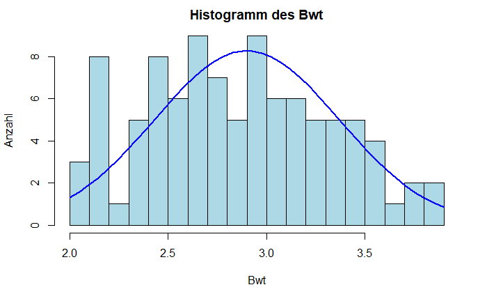

```r
x <- data$Bwt

h <- hist(x, main = "Histogramm des Bwt", xlab = "Bwt", ylab ="Anzahl", col = "lightblue" ,breaks = 15)

xfit<-seq(min(x),max(x),length=40)
yfit<-dnorm(xfit,mean=mean(x),sd=sd(x))
yfit <- yfit*diff(h$mids[1:2])*length(x)
lines(xfit, yfit, col="blue", lwd=2)
```

Kommentar: Die Variable Bwt ist anscheinend normalverteilt. Sie zeigt eine bauchige Mitte und geht an den Rändern gegen null. Auch die Stichprobengröße mit n>30 spricht dafuer. Die Variable Bwt ist verhältnisskaliert, da es sich um eine metrische Größe mit gleichmaessigen Abständen handelt.

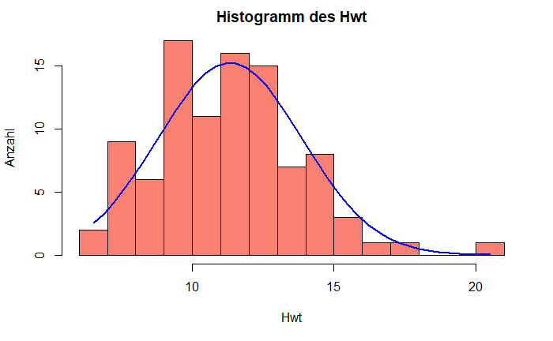

```r
x <- data$Hwt

h <- hist(x, main = "Histogramm des Hwt", xlab = "Hwt", ylab ="Anzahl", col = "salmon" ,breaks = 15)

xfit<-seq(min(x),max(x),length=40)
yfit<-dnorm(xfit,mean=mean(x),sd=sd(x))
yfit <- yfit*diff(h$mids[1:2])*length(x)
lines(xfit, yfit, col="blue", lwd=2)
```

Kommentar: Die Variable Hwt ist anscheinend normalverteilt. Sie zeigt eine bauchige Mitte und geht an den Rändern gegen null. Auch die Stichprobengröße mit n>30 spricht dafuer. Die Variable Hwt ist verhältnisskaliert, da es sich um eine metrische Größe mit gleichmaessigen Abständen handelt.

3. Der untersuchte Zusammenhang zwischen den Variablen muss linear sein -> siehe Streudiagramm

# 3) Grundlegende Konzepte: Was ist Pearson?

Die Korrelation beschreibt den Zusammenhang von zwei verhältnisskalierten Merkmalen/Variablen einer Zufallsstichprobe. Pearson ist die Konzepte zur Berechnung des Korrelationskoeffizienten r nach Bravais und Pearson, damit man die Stärke des Zusammenhangs bestimmen kann.